# PCA

- 통계적으로 상관관계가 없도록 회전하여 성분을 만든다.
- 주성분1을 찾는다. 분산이 가장 크고, 데이터를 가장 잘 표현하는 성분
- 주성분2를 찾는다.
- 상관행렬(상관계수를 표현하는 행렬)에서 대각선을 제외한 모든 값이 0이 된다.

```python
import mglearn
```

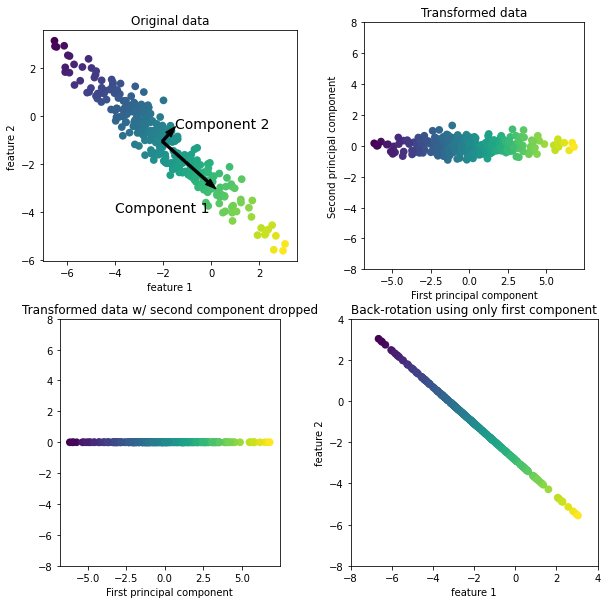

```python
mglearn.plots.plot_pca_illustration()
```

```python
### 한글 폰트 설정
from matplotlib import font_manager, rc
import matplotlib.pyplot as plt
import platform
import matplotlib

path = "C:/Windows/Fonts/malgun.ttf"
if platform.system() == "Windows":
    font_name = font_manager.FontProperties(fname=path).get_name()
    rc('font', family=font_name)
elif platform.system()=="Darwin":
    rc('font', family='AppleGothic')
else:
    print("Unknown System")

matplotlib.rcParams['axes.unicode_minus'] = False
```

## 유방암 데이터 셋에 PCA를 적용

```python
import matplotlib.pyplot as plt
from sklearn.datasets import load_breast_cancer
import numpy as np
```

```python
cancer = load_breast_cancer()
```

```python
# 악성 종양(malignant) : 1
# 양성 종양(benign) : 0
malignant = cancer.data[cancer.target==1]
benign = cancer.data[cancer.target==0]
```

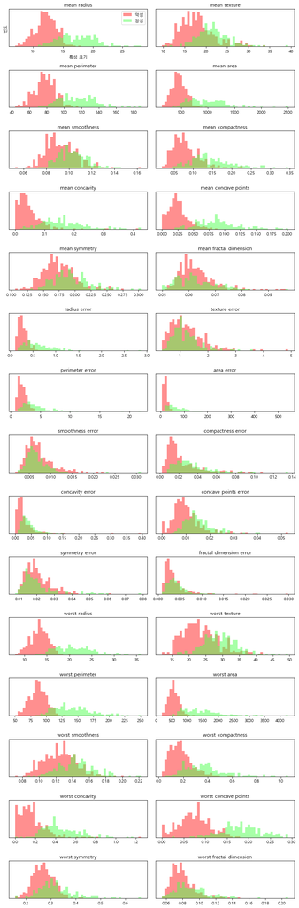

```python
fig, axes = plt.subplots(15, 2, figsize=(10,30))
ax = axes.ravel()

for i in range(30):
    _, bins = np.histogram(cancer.data[:, i], bins=50)
    ax[i].hist(malignant[:, i], bins=bins, color=mglearn.cm3(1), alpha=.5)
    ax[i].hist(benign[:, i], bins=bins, color=mglearn.cm3(2), alpha=.5)
    ax[i].set_title(cancer.feature_names[i])
    ax[i].set_yticks(())

ax[0].set_xlabel("특성 크기")
ax[0].set_ylabel("빈도")
ax[0].legend(["악성", "양성"], loc="best")
fig.tight_layout()
```

## 데이터 전처리 및 PCA 변환

```python
from sklearn.preprocessing import StandardScaler
from sklearn.decomposition import PCA
```

```python
scaler = StandardScaler()
scaler.fit(cancer.data)
X_scaled = scaler.transform(cancer.data)

# X_scaled = scaler.fit_transform(cancer.data) 훈련, 적용 한번에
```

## PCA 적용

- PCA 변환을 학습하고 적용하는 것.
  - (1) PCA 객체를 생성하고, 몇개의 성분을 사용할 것인가?
  - (2) fit 메서드를 호출하여 주성분을 찾고,
  - (3) transform 메서드를 호출하여 데이터를 회전시키고 차원 축소
    - 기본값일 때는 PCA는 데이터를 회전만(이동)만 시키고 모든 주성분을 유지한다.

```python
pca = PCA(n_components=2)
pca.fit(X_scaled)
X_pca = pca.transform(X_scaled)
print("원본 데이터 형태 : {}".format(X_scaled.shape))
print("축소된 데이터 형태 : {}".format(X_pca.shape))
```

```
원본 데이터 형태 : (569, 30)
축소된 데이터 형태 : (569, 2)
```

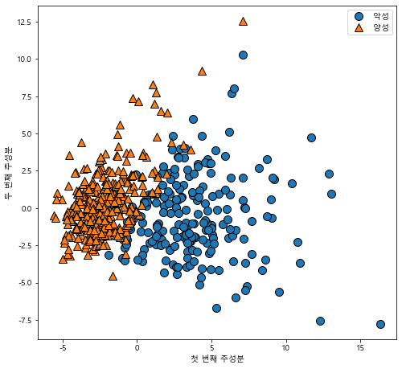

```python
# 클래스를 색깔로 구분하여 처음 두 개의 주성분을 그래프로 표시
plt.figure(figsize=(8, 8))
mglearn.discrete_scatter(X_pca[:, 0], X_pca[:, 1], cancer.target)
plt.legend(["악성", "양성"], loc="best")
plt.gca().set_aspect("equal")
plt.xlabel("첫 번째 주성분")
plt.ylabel("두 번째 주성분")
```

## 주성분 확인

```python
print("PCA 주성분 형태 ", pca.components_.shape)
print("PCA 주성분 :", pca.components_) # 두개의 주성분에 대한 결합- 회귀 계수
```

```
PCA 주성분 형태  (2, 30)
PCA 주성분 : [[ 0.21890244  0.10372458  0.22753729  0.22099499  0.14258969  0.23928535
   0.25840048  0.26085376  0.13816696  0.06436335  0.20597878  0.01742803
   0.21132592  0.20286964  0.01453145  0.17039345  0.15358979  0.1834174
   0.04249842  0.10256832  0.22799663  0.10446933  0.23663968  0.22487053
   0.12795256  0.21009588  0.22876753  0.25088597  0.12290456  0.13178394]
 [-0.23385713 -0.05970609 -0.21518136 -0.23107671  0.18611302  0.15189161
   0.06016536 -0.0347675   0.19034877  0.36657547 -0.10555215  0.08997968
  -0.08945723 -0.15229263  0.20443045  0.2327159   0.19720728  0.13032156
   0.183848    0.28009203 -0.21986638 -0.0454673  -0.19987843 -0.21935186
   0.17230435  0.14359317  0.09796411 -0.00825724  0.14188335  0.27533947]]
```

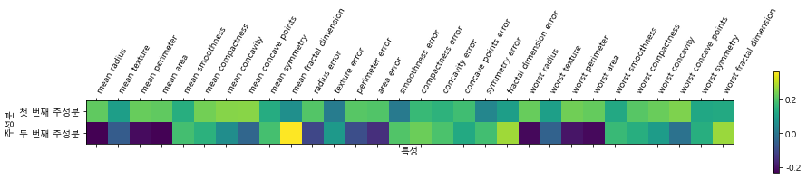

```python
plt.matshow(pca.components_, cmap='viridis')
plt.yticks([0, 1], ["첫 번째 주성분", "두 번째 주성분"])
plt.colorbar()
plt.xticks(range(len(cancer.feature_names)),
           cancer.feature_names, rotation=60, ha='left')
plt.xlabel("특성")
plt.ylabel("주성분")
```

### 실습) PCA를 이용해서 주성분 5개으로 차원 축소를 하고, 이에 대한 성분 그래프를 그려보자.

```python
pca = PCA(n_components=5)
X_pca = pca.fit_transform(X_scaled)
print("원본 데이터 형태 : {}".format(X_scaled.shape))
print("축소된 데이터 형태 : {}".format(X_pca.shape))
```

```
원본 데이터 형태 : (569, 30)
축소된 데이터 형태 : (569, 5)
```

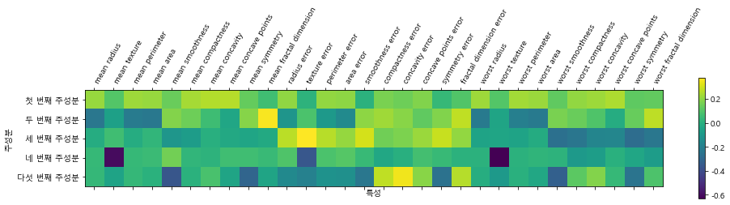

```python
plt.matshow(pca.components_, cmap='viridis')
plt.yticks([0, 1, 2, 3, 4], ["첫 번째 주성분", "두 번째 주성분", "세 번째 주성분", "네 번째 주성분", "다섯 번째 주성분"])
plt.colorbar()
plt.xticks(range(len(cancer.feature_names)),
           cancer.feature_names, rotation=60, ha='left')
plt.xlabel("특성")
plt.ylabel("주성분")
```

## IRIS 데이터 셋을 이용한 PCA 예제 실습

```python
from sklearn.decomposition import PCA
import seaborn as sns
```

```python
iris = sns.load_dataset('iris')

X_iris = iris.drop("species", axis=1)
y_iris = iris['species']

print(X_iris.shape, y_iris.shape)
```

```
(150, 4) (150,)
```

```python
model = PCA()
X_pca_dat = model.fit_transform(X_iris)
print(X_pca_dat.shape, type(X_pca_dat))
```

```
(150, 4) <class 'numpy.ndarray'>
```

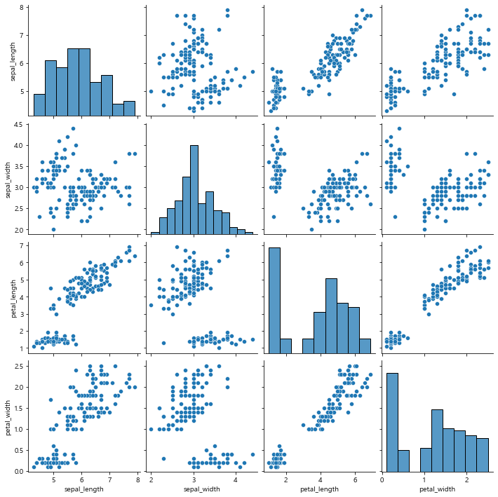

```python
sns.pairplot(iris)
```

```python
import pandas as pd
```

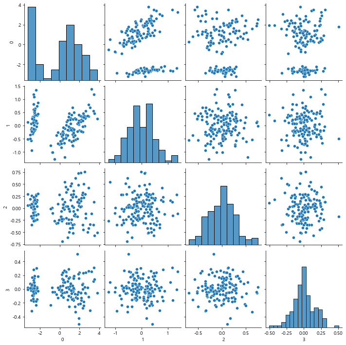

```python
df = pd.DataFrame(X_pca_dat[0:,0:])
sns.pairplot(df)
```

### 실습) 주성분 2개를 만들고, 이를 그래프에 표시해 보자. 그리고 주성분 1, 주성분2는 어떤 X1~X4로 구성되어 있는지 확인해 보자. - 주성분1, 주성분2는 계수 시각화

```python
pca = PCA(n_components=2)
X_pca2_dat = pca.fit_transform(X_iris)
print(X_pca2_dat.shape, type(X_pca2_dat))
```

```
(150, 2) <class 'numpy.ndarray'>
```

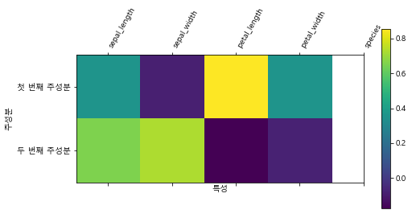

```python
plt.matshow(pca.components_, cmap='viridis')
plt.yticks([0, 1], ["첫 번째 주성분", "두 번째 주성분"])
plt.colorbar()
plt.xticks(range(len(iris.columns)),
           iris.columns, rotation=60, ha='left')
plt.xlabel("특성")
plt.ylabel("주성분")
```

|  | 0 | 1 |
| --- | --- | --- |
| 0 | -2.684126 | 0.319397 |
| 1 | -2.714142 | -0.177001 |
| 2 | -2.888991 | -0.144949 |
| 3 | -2.745343 | -0.318299 |
| 4 | -2.728717 | 0.326755 |
| 5 | -2.280860 | 0.741330 |
| 6 | -2.820538 | -0.089461 |
| 7 | -2.626145 | 0.163385 |
| 8 | -2.886383 | -0.578312 |
| 9 | -2.672756 | -0.113774 |

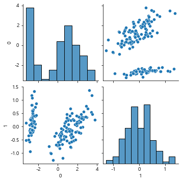

```python
# df = pd.DataFrame(X_pca2[0:,0:])
df = pd.DataFrame(X_pca2_dat)
sns.pairplot(df)
df.head(10)
```

```python
df.corr()
```

|  | 0 | 1 |
| --- | --- | --- |
| 0 | 1.000000e+00 | 6.988097e-17 |
| 1 | 6.988097e-17 | 1.000000e+00 |

```python
iris['PCA1'] = df.iloc[:,0]  # feature 생성
iris['PCA2'] = df.iloc[:,1]  # feature 생성
iris.head()
```

|  | sepal_length | sepal_width | petal_length | petal_width | species | PCA1 | PCA2 |
| --- | --- | --- | --- | --- | --- | --- | --- |
| 0 | 5.1 | 3.5 | 1.4 | 0.2 | setosa | -2.684126 | 0.319397 |
| 1 | 4.9 | 3.0 | 1.4 | 0.2 | setosa | -2.714142 | -0.177001 |
| 2 | 4.7 | 3.2 | 1.3 | 0.2 | setosa | -2.888991 | -0.144949 |
| 3 | 4.6 | 3.1 | 1.5 | 0.2 | setosa | -2.745343 | -0.318299 |
| 4 | 5.0 | 3.6 | 1.4 | 0.2 | setosa | -2.728717 | 0.326755 |

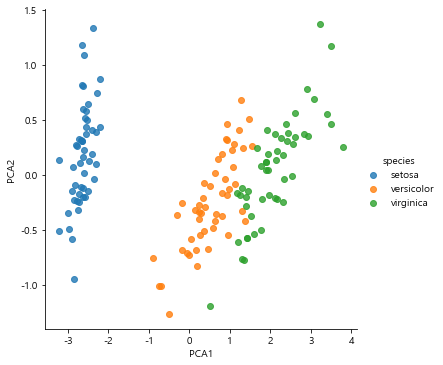

```python
sns.lmplot('PCA1', 'PCA2', hue="species", data=iris, fit_reg=False)
```

```python
iris.columns
```

```
Index(['sepal_length', 'sepal_width', 'petal_length', 'petal_width', 'species',
       'PCA1', 'PCA2'],
      dtype='object')
```

```python
pca.components_
```

```
array([[ 0.36138659, -0.08452251,  0.85667061,  0.3582892 ],
       [ 0.65658877,  0.73016143, -0.17337266, -0.07548102]])
```